# Leroux model in NIMBLE and CARBayes: An example with the Scottish lip cancer data

Garyfallos Konstantinoudis

In this document we will perform disease mapping and spatial regression using `NIMBLE` (de Valpine et al. 2017) and [CARBayes](https://cran.r-project.org/web/packages/CARBayes/vignettes/CARBayes.pdf). We will fit the Leroux prior (Leroux, Lei, and Breslow 2000) in the famous Scottish lip cancer dataset and compare the performance of the different softwares.

# Install and load packages

This practical requires the following packages to be installed and attached: `sf`, `dplyr`, `tidyverse`, `nimble`, `coda`, `spdep`, `patchwork`, `GGally`, `ggmcmc`, `CARBayesdata` and `CARBayes`.

- To install the entire suite of packages, we can use:

```r
install.packages(c("sf", "dplyr", "tidyverse", "nimble", "coda", "spdep", "patchwork",
                   "GGally", "ggmcmc", "CARBayesdata", "CARBayes"), dependencies = TRUE, repos = "http://cran.r-project.org")
```

- Then, load the needed packages:

```r
library(sf)           # Simple feature for R
library(dplyr)        # A package for data manipulation
library(tidyverse)    # A package for data manipulation and plotting


library(nimble)       # A package for performing MCMC in R

library(coda)         # A package for summarizing and plotting of MCMC output
                      # and diagnostic tests
library(spdep)        # A package to calculate neighbors

library(patchwork)    # A package to combine plots
library(GGally)       # A package to do pairplots
library(ggmcmc)       # MCMC diagnostics with ggplot

library(CARBayes)     # A package for fitting CAR models
library(CARBayesdata) # A package with the Scottish lip cancer data
library(kableExtra)   # packages for formatting tables in rmarkdown
```

# Scottish lip cancer data

- Import the health data. Note that Scottish lip cancer can be also loaded from the `CARBayes` package.

```r
data(lipdata)
data(lipdbf)
data(lipshp)
```

- Combine the datasets.

```r
lipdbf$dbf <- lipdbf$dbf[ ,c(2,1)]
data.combined <- combine.data.shapefile(data=lipdata, shp=lipshp, dbf=lipdbf)
```

- Create the neighboring matrix.

```r
W <- poly2nb(data.combined)
W <- nb2mat(W, zero.policy = TRUE, style = "B")
```

# Obtaining the posterior relative risks

## Leroux model

The SIRs will be smoothed using the Poisson-logNormal model. The inference is done with `NIMBLE` called through R. In particular, let each ward $i$ be indexed by the integers $1, 2,...,N$. The model is as follows:
$$\begin{eqnarray}
O_{i}|\lambda_{i} & \sim & \text{Poisson}(\lambda_{i}E_{i} ) \\
\log(\lambda_{i}) & = & \alpha + \phi_{i} \\
\phi & \sim & N\Big(0,\tau_{\phi}^{-1}\big((1-\rho){\bf I} + \rho{\bf Q}^{-}\big)\Big)
\end{eqnarray}$$

where $O_i$ is the observed number of scottish lip cancer cases, $E_{i}$ the expected, $\alpha$ is an intercept term denoting the average log SIR, $\phi_{i}$ is a random intercept and $\tau_{\theta}$ a precision (reciprocal of the variance) term that controls the magnitude of $\theta_{i}$.

## Code

### CARBayes

- We will first write the model in CARBayes:

```r
# Chain 1
t_0 <- Sys.time()
chain1 <- S.CARleroux(formula= observed ~ 1 + offset(log(expected)),
                      data=data.combined,
                      family="poisson",
                      W=W,
                      burnin=10000,
                      n.sample=50000,
                      thin=2,
                      prior.mean.beta=0,        # mean of the normal prior of the intercept
                      prior.var.beta=1,         # var of the normal prior of the intercept
                      prior.tau2 = c(1, 0.01),  # the shape and scale of Inv-Gamma
                      verbose = FALSE)
t_1 <- Sys.time()
t_chain1CARBayes <- t_1 - t_0

# Chain 2
t_0 <- Sys.time()
chain2 <- S.CARleroux(formula= observed ~ 1 + offset(log(expected)),
                      data=data.combined,
                      family="poisson",
                      W=W,
                      burnin=10000,
                      n.sample=50000,
                      thin=2,
                      prior.mean.beta=0,
                      prior.var.beta=1,
                      prior.tau2 = c(1, 0.01),
                      verbose = FALSE)
t_1 <- Sys.time()
t_chain2CARBayes <- t_1 - t_0

t_CARBayes <- t_chain1CARBayes + t_chain2CARBayes
```

### NIMBLE

- Define the precision matrix of Leroux.

```r
Q <- matrix(0, nrow = nrow(W), ncol = ncol(W))
diag(Q) <- apply(W, 1, sum)
Q <- Q - W
```

- We will then write the model in nimble:

```r
LerouxCode <- nimbleCode(
  {
    for (i in 1:N){

      O[i] ~ dpois(mu[i])
      log(mu[i]) <- log(E[i]) + alpha + theta.centred[i]
      SIR[i] <- exp(alpha + theta.centred[i])

      theta.centred[i] <- theta[i] - theta.mean
    }

    PrecMat[1:N, 1:N] <- tau.theta*(rho*Q[1:N, 1:N] + (1 - rho)*diag(N))
    theta[1:N] ~ dmnorm(mean = mu_ler[1:N], prec = PrecMat[1:N,1:N])

    theta.mean <- sum(theta[1:N])/N

    # intercept
    alpha ~ dnorm(0, tau = 1)

    # precision
    tau.theta ~ dgamma(1, 0.01)
    sigma2.theta <- 1/tau.theta

    # mixing
    rho ~ dunif(0,1)

  }
)
```

- Define the data object for `NIMBLE`

```r
N = nrow(data.combined)

ScotLipdata = list(
  O = data.combined$observed
)

ScotLipConsts <-list(
  N = N,
  E = data.combined$expected,
  Q = Q,
  mu_ler=rep(0, N)

)
```

- Initialise the unknown parameters, 2 chains.

```r
inits <- list(
  list(alpha=0.01, tau.theta=10, theta = rep(0.01,times=N), rho = 0.5),  # chain 1
  list(alpha=0.5, tau.theta=1, theta = rep(-0.01,times=N), rho = 0.7) # chain 2
)
```

- Set the parameters that will be monitored.

```r
params <- c("sigma2.theta", "SIR", "alpha", "rho", "theta", "theta.centred")
```

Note that the parameters that are not set, will NOT be monitored!

- Specify the MCMC setting.

```r
ni <- 100000  # nb iterations
nt <- 5       # thinning interval
nb <- 50000   # nb iterations as burn-in
nc <- 2       # nb chains
```

- Run the MCMC simulations calling Nimble from R using the function `nimbleMCMC()`.

```r
t_0 <- Sys.time()
Lerouxsamples <- nimbleMCMC(code = LerouxCode,
                            data = ScotLipdata,
                            constants = ScotLipConsts,
                            inits = inits,
                            monitors = params,
                            niter = ni,
                            nburnin = nb,
                            thin = nt,
                            nchains = nc,
                            setSeed = 9,
                            progressBar = TRUE,
                            samplesAsCodaMCMC = TRUE,
                            summary = TRUE
)
t_1 <- Sys.time()
t_smallsetting <- t_1 - t_0
```

## Check convergence

### CARBayes

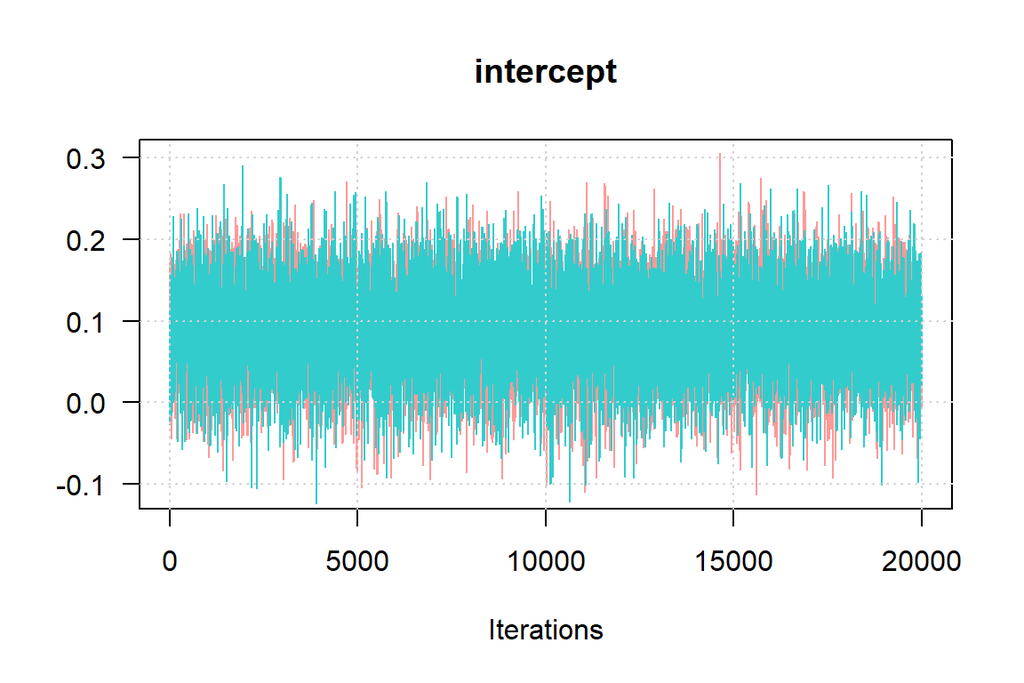

```r
traceplot(chain1$samples$beta, las = 1, main = "intercept", col = "#ff9999")
traceplot(chain2$samples$beta, add = TRUE, col = "#33cccc")
grid()
```

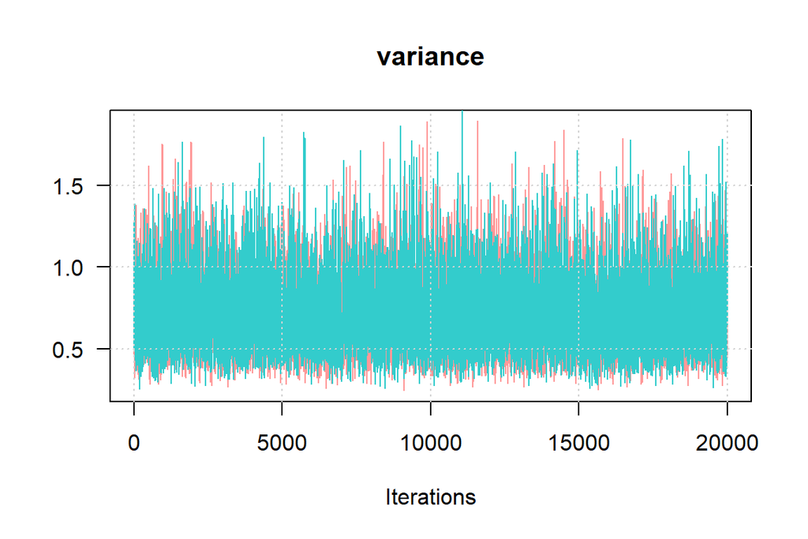

```r
traceplot(chain1$samples$tau2, las = 1, main = "variance", col = "#ff9999")
traceplot(chain2$samples$tau2, add = TRUE, col = "#33cccc")
grid()
```

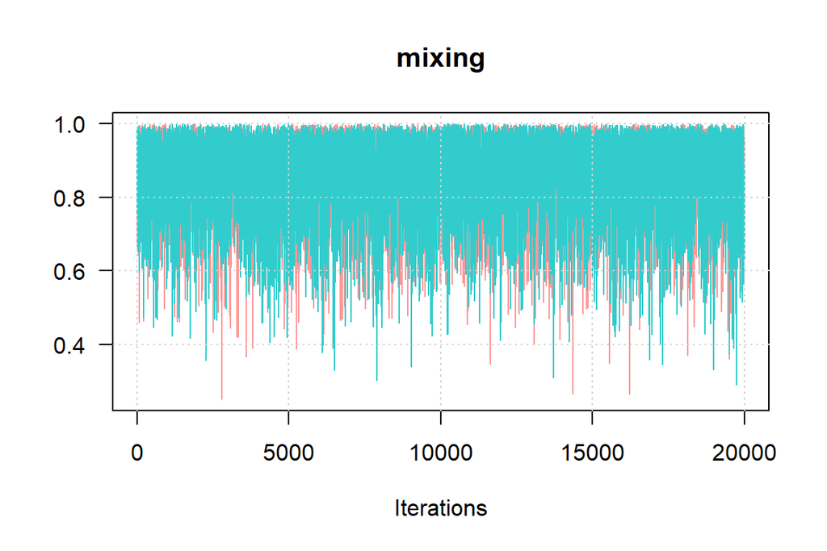

```r
traceplot(chain1$samples$rho, las = 1, main = "mixing", col = "#ff9999")
traceplot(chain2$samples$rho, add = TRUE, col = "#33cccc")
grid()
```

### NIMBLE

- The same plots in `NIMBLE`.

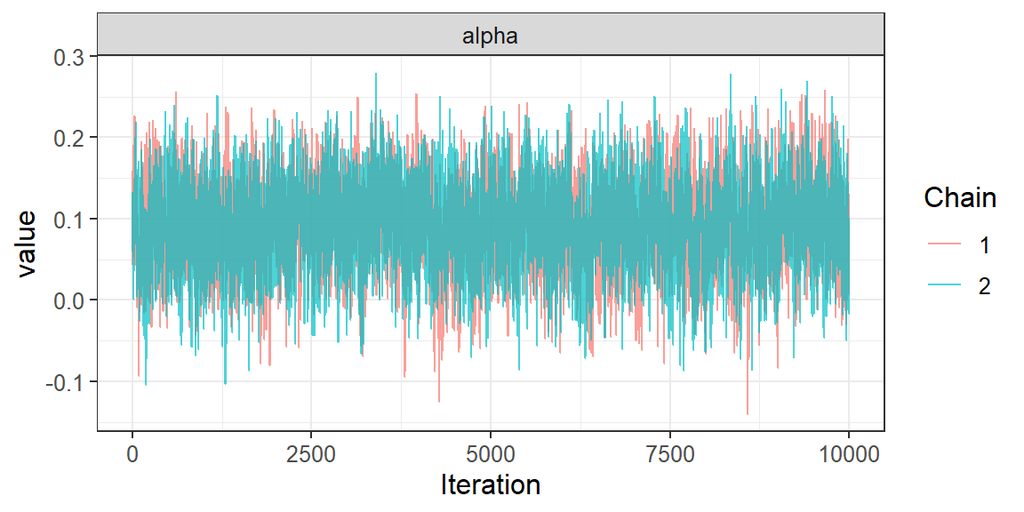

```r
ggLerouxNIMBLE <- ggs(Lerouxsamples$samples)

ggLerouxNIMBLE %>% filter(Parameter == "alpha") %>%
  ggs_traceplot + theme_bw() + theme(text = element_text(size = 12))
```

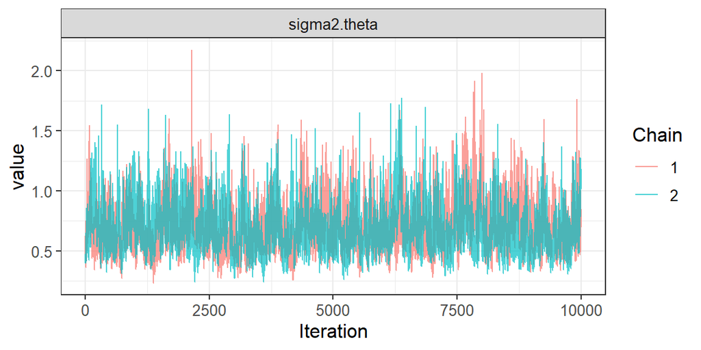

```r
ggLerouxNIMBLE %>% filter(Parameter == "sigma2.theta") %>%
  ggs_traceplot + theme_bw() + theme(text = element_text(size = 12))
```

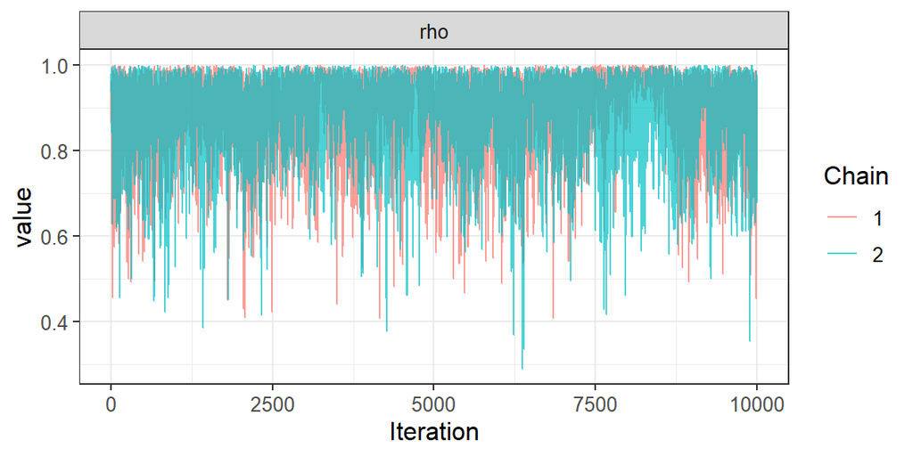

```r
ggLerouxNIMBLE %>% filter(Parameter == "rho") %>%
  ggs_traceplot + theme_bw() + theme(text = element_text(size = 12))
```

## Comparison of the results

### Time to convergence

From the first look, CARBayes needs less time (14 sec) and samples to converge compared to the NIMBLE specification shown in this tutorial (1.8 minutes). We should consider the current differences in the samplers, for instance CARBayes uses block sampling for the random effects, whereas in our NIMBLE specification we do not have block sampling.

### Check tables

```r
data.frame(
  rbind(
  c("", "CARBayes", ""),
  c("Median", "LL", "UL"),
round(
rbind(
  round(chain1$summary.results[,1:3], digits= 2)
), digits = 2
),
  c("", "NIMBLE", ""),
  round(
  Lerouxsamples$summary$all.chains["alpha", c("Median", "95%CI_low", "95%CI_upp")],
  digits = 2),
  round(
  Lerouxsamples$summary$all.chains["sigma2.theta", c("Median", "95%CI_low", "95%CI_upp")],
  digits = 2),
  round(
  Lerouxsamples$summary$all.chains["rho", c("Median", "95%CI_low", "95%CI_upp")],
  digits = 2)
)
) -> tab


tab <- cbind(c("", "", "intercept", "variance", "mixing", "", "intercept", "variance", "mixing"),
             tab)

colnames(tab) <- NULL
row.names(tab) <- NULL

knitr::kable(tab, caption = "Median and 95%CrI for the intercept and hyperparameters of the models.") %>%
  kable_styling(bootstrap_options = "striped", full_width = F, position = "center")
```

Median and 95%CrI for the intercept and hyperparameters of the models.

|  |  | CARBayes |  |
| --- | --- | --- | --- |
|  | Median | LL | UL |
| intercept | 0.09 | -0.02 | 0.19 |
| variance | 0.67 | 0.39 | 1.16 |
| mixing | 0.89 | 0.62 | 0.99 |
|  |  | NIMBLE |  |
| intercept | 0.09 | -0.01 | 0.19 |
| variance | 0.66 | 0.39 | 1.17 |
| mixing | 0.92 | 0.66 | 0.99 |

### Check densities

1. CARBayes

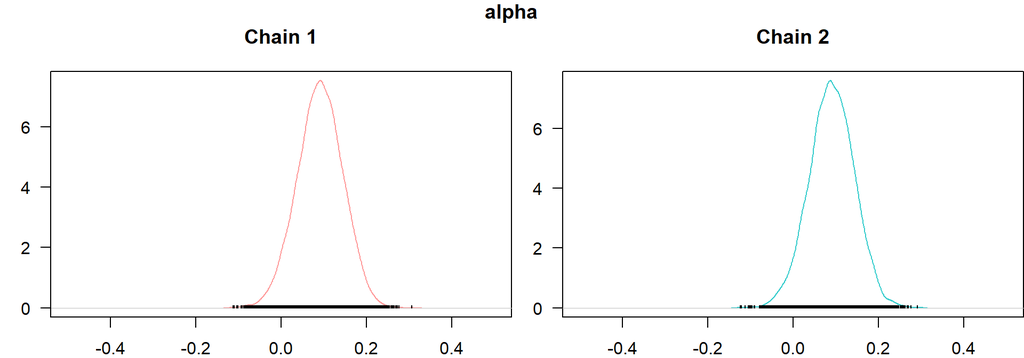

```r
par(mfrow = c(1,2), mar = c(2, 2.5, 3.5, 0))
densplot(chain1$samples$beta, las = 1, main = "Chain 1",
         xlim = c(-0.5,0.5), col = "#ff9999")

densplot(chain2$samples$beta, col = "#33cccc",
         las = 1, main = "Chain 2", xlim = c(-0.5,0.5))
title("alpha", outer = TRUE, line = -.9)
```

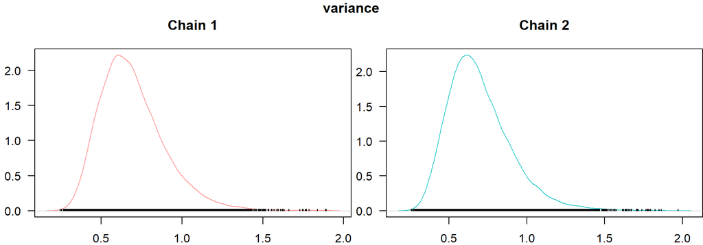

```r
densplot(chain1$samples$tau2, las = 1, main = "Chain 1",
         col = "#ff9999")
densplot(chain2$samples$tau2, col = "#33cccc", las = 1, main = "Chain 2")
title("variance", outer = TRUE, line = -.9)
```

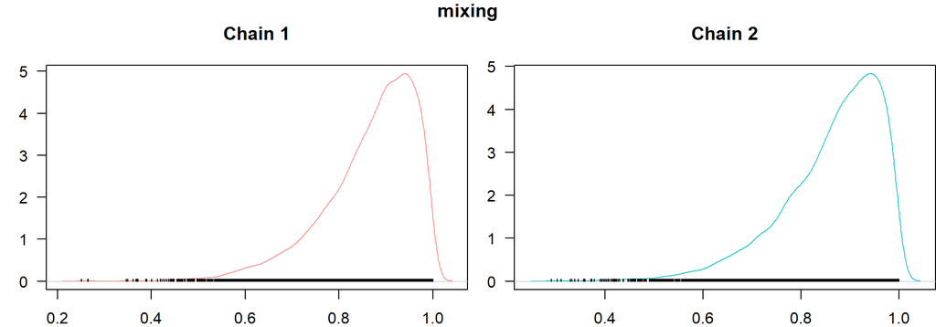

```r
densplot(chain1$samples$rho, las = 1, main = "Chain 1",
         col = "#ff9999")
densplot(chain2$samples$rho, col = "#33cccc", las = 1, main = "Chain 2")
title("mixing", outer = TRUE, line = -.9)
```

2. NIMBLE

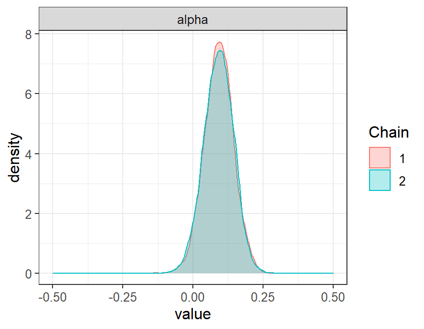

```r
ggLerouxNIMBLE %>% filter(Parameter == "alpha") %>%
  ggs_density() + theme_bw() + theme(text = element_text(size = 12)) +
  xlim(c(-0.5,0.5))
```

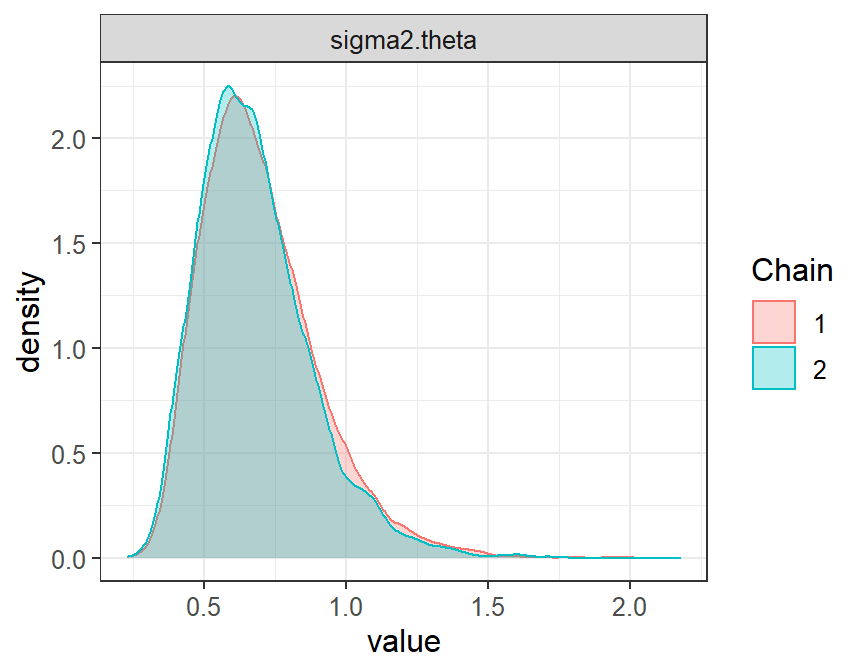

```r
ggLerouxNIMBLE %>% filter(Parameter == "sigma2.theta") %>%
  ggs_density() + theme_bw() + theme(text = element_text(size = 12))
```

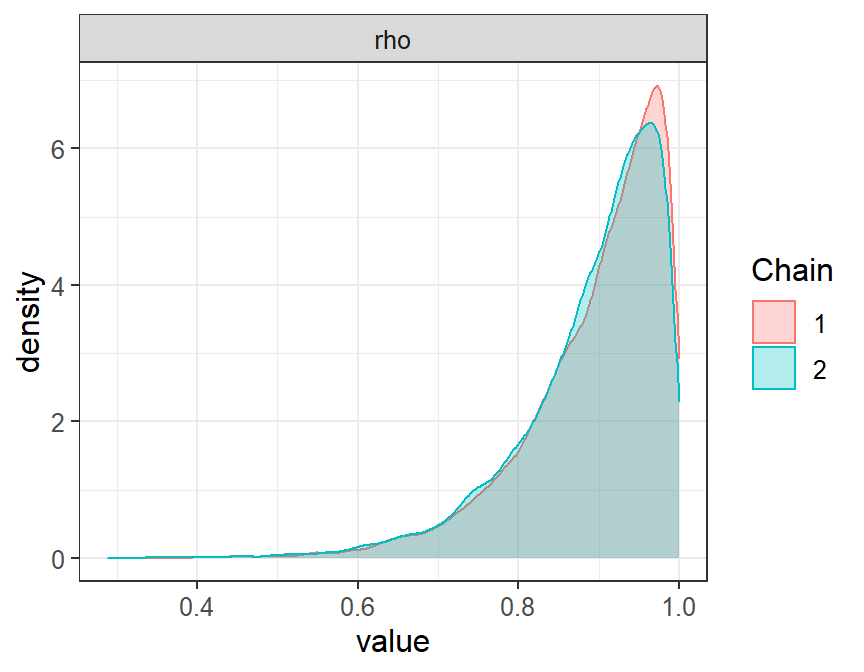

```r
ggLerouxNIMBLE %>% filter(Parameter == "rho") %>%
  ggs_density() + theme_bw() + theme(text = element_text(size = 12))
```

### Random effects

1. Median

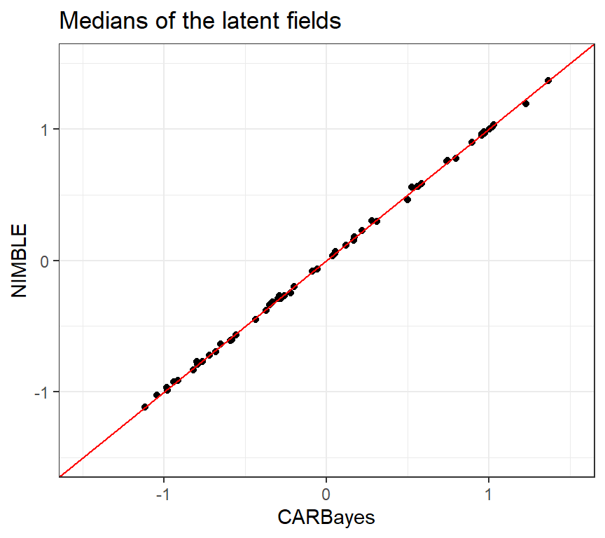

```r
dat.points <- data.frame(CARBayes = apply(chain1$samples$phi, 2, median),
                         NIMBLE =
                         Lerouxsamples$summary$all.chains[paste0("theta.centred[",
                                            1:nrow(data.combined),"]"), "Median"])

ggplot() + geom_point(data = dat.points, aes(x = CARBayes, y = NIMBLE)) +
  theme_bw() + ylim(c(-1.5, 1.5)) + xlim(c(-1.5, 1.5)) +
  ggtitle("Medians of the latent fields") + geom_abline(a = 0, b = 1, col = "red")
```

2. Standard deviations

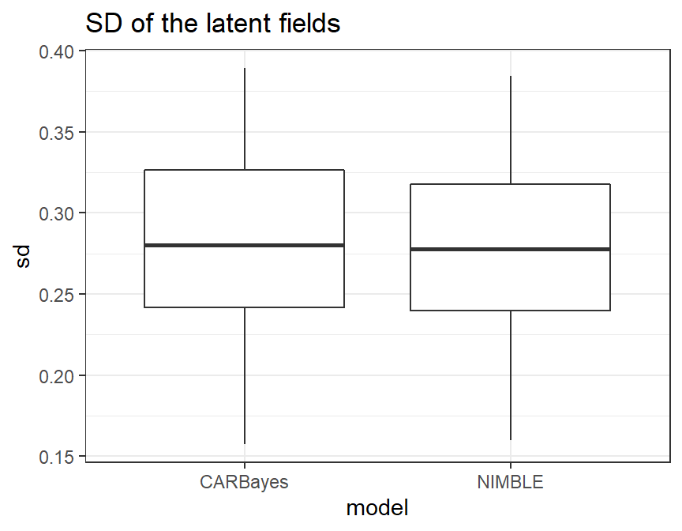

```r
dat.box <- data.frame(sd = c(Lerouxsamples$summary$all.chains[paste0("theta.centred[",
                      1:nrow(data.combined), "]"), "St.Dev."],
                             apply(chain1$samples$phi, 2, sd)),
                      model = c(rep("NIMBLE", times = nrow(data.combined)),
                                rep("CARBayes", times = nrow(data.combined))))

ggplot() + geom_boxplot(data = dat.box, aes(x = model, y = sd)) + theme_bw() +
  ggtitle("SD of the latent fields")
```

### SMRs

1. Medians

```r
mat <- matrix(NA, nrow = 20000, ncol = nrow(data.combined))
for(i in 1:nrow(data.combined)){

  mat[,i] <- exp(chain1$samples$beta + chain1$samples$phi[,i])

}

cor(Lerouxsamples$summary$all.chains[paste0("SIR[",
    1:nrow(data.combined), "]"), "Median"],
    apply(mat, 2, median))
```

```
## [1] 0.9997017
```

2. Standard deviations

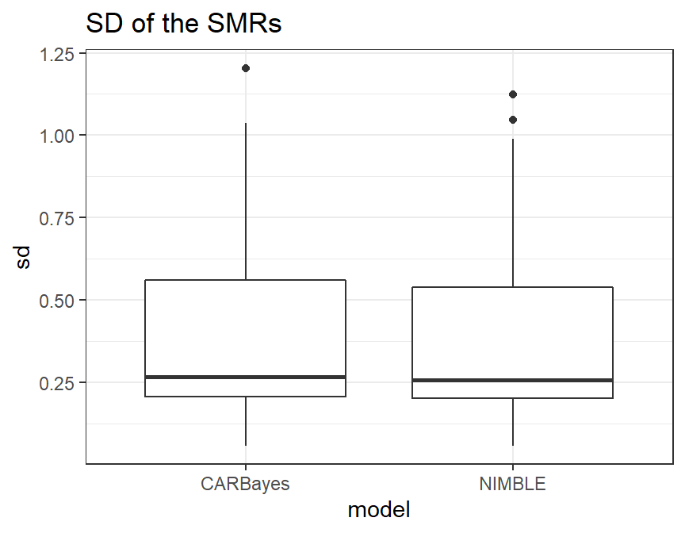

```r
dat.box <- data.frame(sd = c(Lerouxsamples$summary$all.chains[paste0("SIR[",
                      1:nrow(data.combined), "]"), "St.Dev."],
                             apply(mat, 2, sd)),
                      model = c(rep("NIMBLE", times = nrow(data.combined)),
                                rep("CARBayes", times = nrow(data.combined))))


ggplot() + geom_boxplot(data = dat.box, aes(x = model, y = sd)) + theme_bw() +
  ggtitle("SD of the SMRs")
```

The results are very similar (almost identical) with respect to the SMRs.

## Conclusion

This tutorial is a first attempt to fit the Leroux model in `NIMBLE`. We compared the results with the `CARBayes` package which is the standard when it comes to fitting the Leroux model. The results are almost identical, nevertheless nimble needs slightly more time to converge. Future work includes a block sampling implementation (as is currently in `CARBayes`) in `NIMBLE`.

# References

de Valpine, P., D. Turek, C. J. Paciorek, C. Anderson-Bergman, D. Temple Lang, and R. Bodik. 2017. “Programming with Models: Writing Statistical Algorithms for General Model Structures with NIMBLE.” *Journal of Computational and Graphical Statistics* 26: 403–17. https://doi.org/10.1080/10618600.2016.1172487.

Leroux, Brian G, Xingye Lei, and Norman Breslow. 2000. “Estimation of Disease Rates in Small Areas: A New Mixed Model for Spatial Dependence.” In *Statistical Models in Epidemiology, the Environment, and Clinical Trials*, 179–91. Springer.